# Introduction

Penalty kick shootouts are a key part of tournament soccer. If the match is tied after regulation and/or overtime, a shootout determines the winner. Goalkeepers are crucial in these moments. A goalkeeper who is able to save multiple shots greatly increases his or her team's chance of winning.

Managers face a tough decision when going into a shootout. Most teams have two or three goalkeepers on the roster, and the starting goalkeeper might not be the best for the specialized skill of blocking shots in a shootout. Several managers will substitute the goalkeeper right before the shootout so the goalkeeper with the highest *save rate* will participate in the shootout.

But how does a manager determine which goalkeeper has the highest *save rate*? This project explores this question.

*ASSUMPTION*

For simplicity throughout the exercise, we will assume that each goalkeeper has an inherent *true save rate*. This does not change over time or with practice. Whether the goalkeeper saves a given shot is a random variable. The goalkeeper saves the shot with probability *true save rate* or the shot is scored.

# Approach 1: Classical A/B Testing

Let's start with the *Classical* approach from statistics (this is also the *frequentist method*)

A coach has two goalkeepers on her roster: Buffon and Casillas. She wants to know which goalkeeper has a higher *save rate*. The coach plans an experiment.

> During training sessions, each goalkeeper will face a number of penalty kick shots from several different shooters. The coach will record whether each shot is saved and use this data to determine which goalkeeper has the higher save rate or if they are the same.

*How many shots should each goalkeeper face during the experiment?*

The coach knows that the average save rate among all goalkeepers is about [25%](https://theanalyst.com/2024/05/premier-league-penalties-like-free-goal). She reasons that it is important to be able to detect a difference of 5% or greater between the true save rates of each goalkeeper.

To decide how many shots each goalkeeper should face, the coach googles around online and lands on this [calculator](https://www2.ccrb.cuhk.edu.hk/stat/proportion/Casagrande.htm) from the center for clinical research and biostats.

The coach puts the values into the calculator and...

[figure not shown]

Each goalkeeper needs to face 1964 shots to ensure we pick up the difference!!!

## Simulation

The coach is unsure about the calculation for the number of shots each goalkeeper must face. She phones her friend who is a high school stats teacher and asks her to run a few scenarios.

### Scenario 1

In scenario 1, let's say Buffon has a save rate of 25% and Casillas has a save rate of 30%

```
Buffon observed save rate: 0.25712830957230143
Casillas observed save rate: 0.29989816700611
t-statistic: -2.9925444155512966
p-value: 0.0027838473919743786

GOALKEEPERS HAVE STATISTICALLY DIFFERENT SAVE RATES
```

The teacher runs a test assuming the goalkeepers have the given save reates. If we have each goalkeeper face 1964 shots, we correctly identify that Casillas is the better goalkeeper

### Scenario 2

The coach now wants to assume they are a bit closer. Buffon's save rate is 28% and Casillas's is 30%

```
Buffon observed save rate: 0.285132382892057
Casillas observed save rate: 0.29989816700611
t-statistic: -1.017011955201561
p-value: 0.3092104104051458

GOALKEEPERS HAVE STATISTICALLY EQUIVALENT SAVE RATES
```

The teacher again runs the test. In this scenario, we spend nearly 4000 penalty kicks to not even pick up the different save rates

### Scenario 3

The coach now asks for the opposite: Casillas is much better than Buffon. Buffon's save rate is 20% and Casillas's is 30%

```
Buffon observed save rate: 0.1985743380855397
Casillas observed save rate: 0.29989816700611
t-statistic: -7.3892208234977765
p-value: 1.7948181949503553e-13

GOALKEEPERS HAVE STATISTICALLY DIFFERENT SAVE RATES
```

The teacher runs the experiment, and it clearly picks up the difference. But she notices something: did we need to shoot nearly 4000 penalty kicks to learn that Casillas is superior?

[output not shown]

## Conclusion

The simulation laid bare some of the drawbacks of the classical approach to this problem:

- The coach does not want to spend hours taking 4000 penalty kicks. That time could be spent on more impactful training
- If the goalkeepers have similar, but not *equivalent*, save rates (as in scenario 2), we still will not identify the correct goalkeeper
- If the goalkeepers are vastly different (as in scenario 3), we don't want to complete the experiment
- While there are tests (like the [Chi-squared](https://en.wikipedia.org/wiki/Chi-squared_test)) that scale to multiple goalkeepers, they often only test if one goalkeeper is *different*, not which one is best
- What if the team faces a shootout before they can complete the experiment? They need a way to choose a goalkeeper with incomplete data

This exposes a tension called *The Explore Exploit Dilemma*.

On one hand we want to *explore* and collect more data (have both goalkeepers face more shots).

On the other hand, we want to **exploit** and make sure the better goalkeeper faces as many shots as possible, since he will save more.

Our first approach does not handle this tension in a satisfactory way. Let's turn to a new way of thinking.

# Approach 2: Epsilon Greedy

The team has made a couple additions to its roster. First, the team has added a new goalkeeper named Neuer. The coach now has to select between the three goalkeepers which has the best save rate.

The team has also added an analyst to use data to improve performance. The coach meets with the analyst and pitches him the problem of deciding which goalkeeper has the highest save rate. The coach wants to vet what the analyst suggests before doing the experiment, so they decide to simulate the analyst's approach and talk about the results.

The analyst proposes this experiment.

> To start, assume all goalkeepers have a save rate of 0. Before each shot, select a random number between 1 and 10.
- If we select 1, choose a goalkeeper at random and have them face the next shot. Update our estimated save rate for that goalkeeper based on if they save the shot or not.
- If we select a number between 2 and 10, choose the goalkeeper with the highest estimated save rate to face the next shot. Update our estimated save rate for that goalkeeper based on if they save the shot or not.

## Simulation

### Code for Simulation

### Code to Plot Results

#### Experiment

#### Simulation

### Run Simulation

The analyst runs his simulation with the following parameters:

- We run each experiment for 1000 trials
  - A "trial" is one shot
- We simulate 100 experiments
  - In real life, we will only do 1 experiment. Simulating 100 gives us a sense of how much we can trust the results from doing just one
- Buffon has a save rate of 20%, Casillas 25%, and Neuer 30%.
  - In real life, we won't know these beforehand, but setting them can guide our evaluation of our process
  - We want our method to identify Neuer as the best goalkeeper as quickly as possible
  - We also want our process to accurately predict the save rate of each goalkeeper

The coach and the analyst sit down to go over the results. The analyst starts by breaking down what happened in a single experiment.

## Results

### Experimental Results

This first chart shows the *exploit rate* over time. Remember, 10% of the time we *explore* by selecting a goalkeeper at random to face the shot. The other 90% of the time we *exploit* and have the goalkeeper with the best estimated save rate face the shot.

We can see that throughout our experiment, our exploit rate stayed very close to the expected 90%

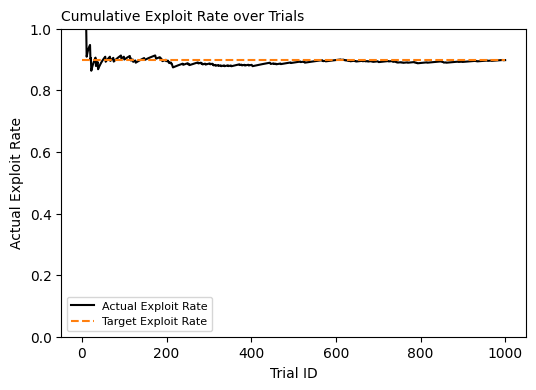

Next, we chart our save rate over time. Our *save rate* is the percent of times we have saved the shot *regardless of which goalkeeper faced the shot*.

Our target here is 30% - the highest save rate among all the goalkeepers. If Neuer, our best goalkeeper, faced every shot, we would expect a save rate of about 30%.

We can see that the longer the experiment goes on, the closer we get to our target. This suggests that throughout the experiment we get better at identifying who the best goalkeeper is and selecting them to face the next shot when we exploit. We do, however, explore throughout the entire experiment, so with this method we would not expect to ever achieve a 30% save rate.

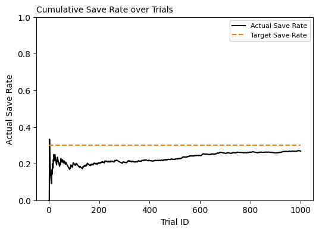

Remember that Neuer is our best goalkeeper. This chart shows the percent of shots that Neuer faces throughout the experiement.

Ideally, we would want our best goalkeeper to face every shot, so the target here is 100%.

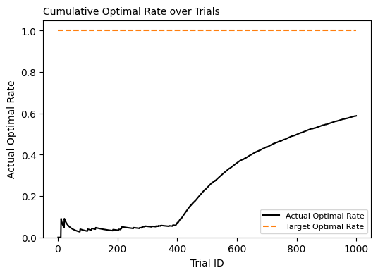

This chart shows the true save rate and estimated save rate for each goalkeeper over time. The dashed lines are the true rates and the sold lines are our estimates.

In this experiment, we can see that Buffon made a save early on while the others were scored on. This led us to believe Buffon had the best rate and have him face more shots.

Casillas then made a couple saves around 75 shots in. This led us to believe he was the best goalkeeper. He, however, failed to save subsequent shots and his estimate dropped back below Buffon.

Since we suspected Buffon and Casillas of better save rates, we actually selected Neuer so few times that he does not save a shot until the 200th shot of the experiment. With more shots, however, we see his estimated save rate climb. By the 400th shot of the experiement, his estimated save rate is above the other two goalkeepers. We continue to have him face more and more shots and his estimated save rate converges to his true 30% mark.

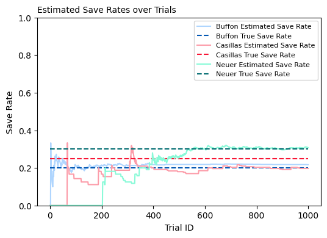

This final chart shows who we thought was the best goalkeeper after each shot. So for example, if we had stopped our experiement after 10 trials, the bar is blue and we would have chosen Buffon as our top goalkeeper. If we had stopped after 320 trials, the bar is red and we would have selected Casillas as our best goalkeeper. After 500 trials, the bar is teal, and we would have selected Neuer.

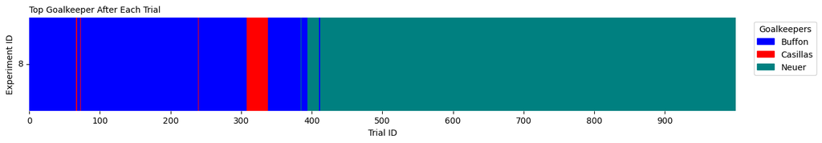

### Simulation Results

The above results were for one experiment and mimic what we will do in real life. Remember, though, that we did a simulation of 100 experiments. We can aggregate the results off all those experiments to estimate what a likely outcome for our real-life experiment will be.

We consolidate all the charts into a single graphic to summarize the whole simulation. Each chart is an extension of one above.

- The chart in the top left plots the **exploit rate**. Similar to the exploit rate chart for a single experiment, the target is still in orange at 90%. In this case, the black line is the *average exploit rate* after the given *trial_id (shot)* across *all 100 experiments*. The gray shading represents one standard deviation above and below the average.
- The chart in the top right plots the **save rate**. The orange is the target, the black is the average across all experiments, and the gray shading is a standard deviation above and below the average.
- The chat in the middle left plots the **optimal rate**. The orange is the target, the black is the average across all experiments, and the gray shading is a standard deviation above and below the average.
- The chart in the middle right plots the **estimated save rate for each goalkeeper**. Each dashed gray line represents the true save rate for one of the goalkeepers. The solid colored lines show the average estimated save rate across all experiments for each goalkeeper. The shading shows one standard deviation above and below the average for each goalkeeper.
- The chart in the bottom right (I know I'm going out of order but you'll see why when you keep reading) plots the **selected goalkeeper** after each trial for each experiment. Each row is one experiment and each column is a trial. The color indicates which goalkeeper we suspect has the best save rate after each trial
- The chart in the bottom left is a new chart and a derivative of the chart in the bottom right. The chart shows the *percent of experiments* in which we would have chosen each goalkeeper after each trial.
  - For example, if we would have stopped each experiment in our simulation after 200 trials, we would have selected Buffon as our best goalkeeper in about 20% of experiments, Casillas as our best goalkeeper in about 25% of experiments, and Neuer as our best goalkeeper in about 55% of experiments.

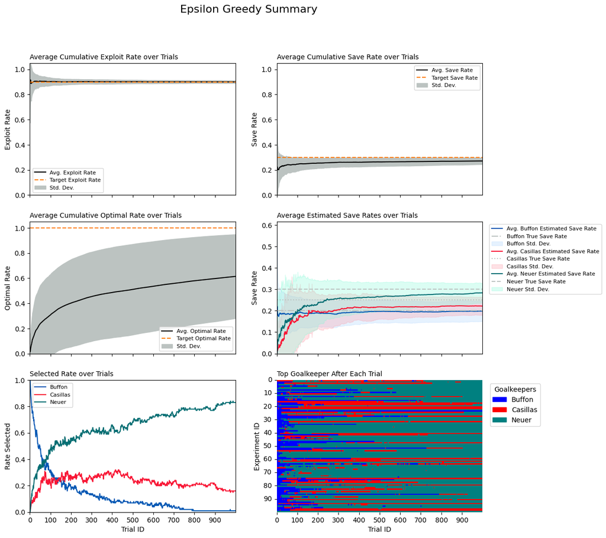

## Conclusion

The coach feels much better about this approach than the previous. Whereas the first method called for taking 4000 shots with an unsure outcome, this second method gives her some expectations.

Assuming the save rates are different, but within 10%, she can expect that an experiment that is 1000 shots long will tell her the best goalkeeper about 80% of the time. An experiment 500 shots long will correctly tell her the best goalkeeper 60% of the time.

Before the coach goes ahead with the experiment, the analyst has one caveat: *the results are highly dependent on the order we select the goalkeepers.* In the above simulation, in the case of a tie for estimated save rate, we choose Buffon. The analyst has run two other simulations, one with Casillas breaking the tie and one with Neuer.

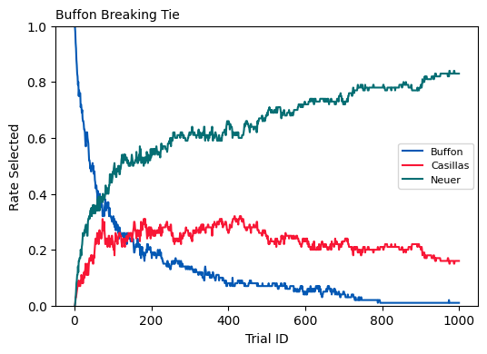

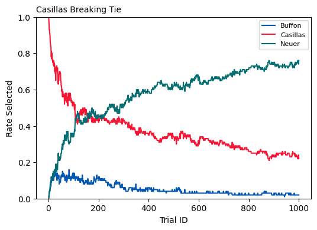

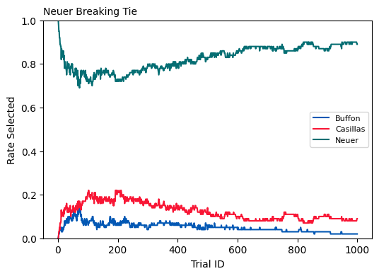

The results vary quite widely. The coach is much less enthused now with the approach. She will not know beforehand the true save rate of each goalkeeper and thus will not be able to choose a good order.

The analyst suggests that we need to *explore* more in the beginning of the experiment to establish some baseline save rates for each goalkeeper. That should make later results where we *exploit* by choosing the best goalkeeper more stable.

There are a few ways to approach this. One would be changing the *epsilon*, or the rate at which we explore. We could make this higher, or we could use an epsilon that *decays*, meaning we would explore more at the beginning of the experiment and less at the end.

The analyst, however, has a different approach in mind...

# Approach 3: Optimistic Initial Values

The analyst proposes this modified experiment.

> Assume all goalkeepers have an impossibly high save rate (5, for example). For each shot, choose the goalkeeper with the highest estimated save rate to face the next shot.
- This forces the algorithm to explore early on. Even if the first goalkeeper saves the first shot (save rate = 1), their estimated save rate will fall from the initial estimate of 5. We will then select a different goalkeeper to face the next shot
- The higher the initial estimated save rate, the more we will explore early on

## Simulation

### Code for Simulation

### Run Simulation

## Results

The analyst finds some notable results in the new approach:

- The chart in the top left shows we are no longer using epsilon to explore
- The chart in the top right shows we get much closer to our target true save rate with this method.
- The chart in the middle right shows the estimated save rates starting at 5 and coming down to the true save rates.
  - Here, though, we see that the rates for Casillas and Buffon do not converge to their true rates. Instead, as soon as the estimates drop below Neuer, they stay constant since we no longer explore those goalkeepers.

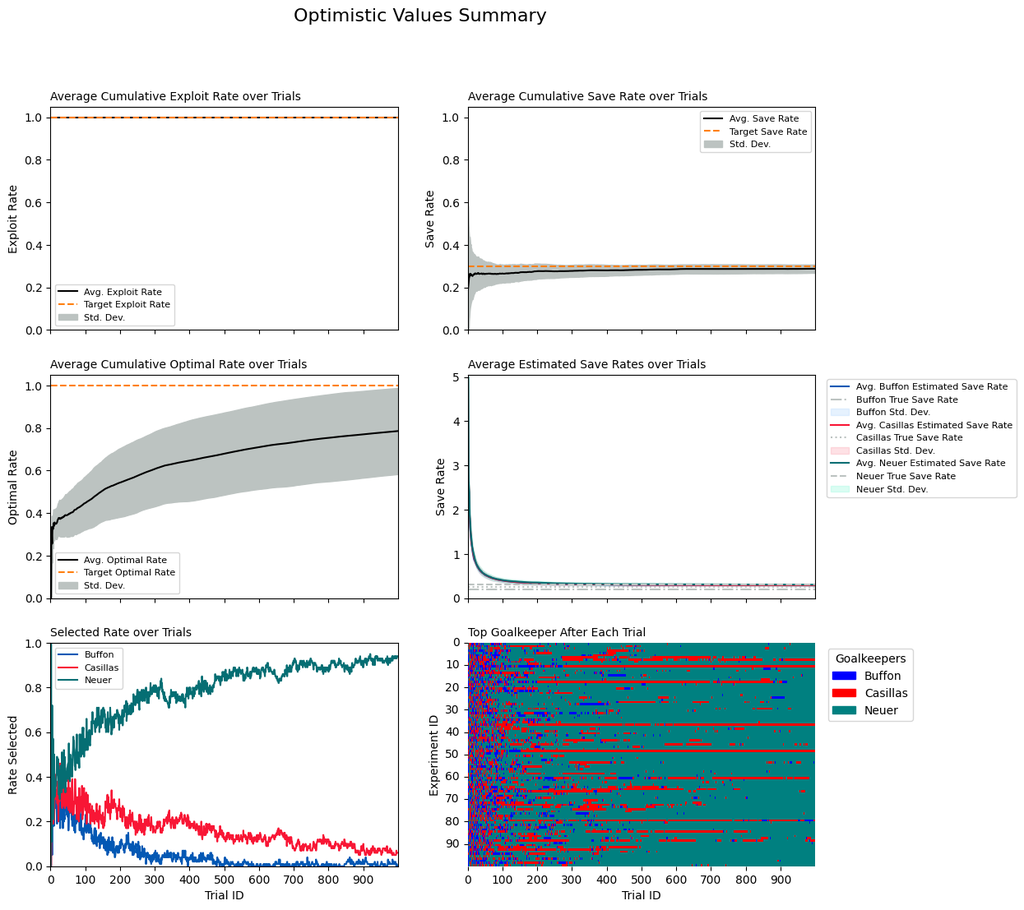

### Optimal Rate

Let's do a deep dive on the optimal rate chart (middle left above).

- With the optimistic values approach, we begin selecting the correct goalkeepr much quicker.
  - With the epsilon greedy approach, it takes about 200 trials to select the correct goalkeeper 40% of the time. By contrast, it takes only about 50 trials with the optimistic values approach
- Our uncertainty using the second method is much smaller, meaning we can be much more confident in our estimate using the optimistic values approach.

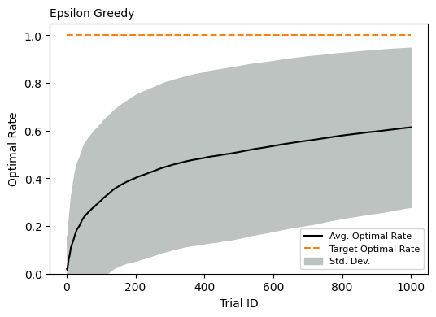

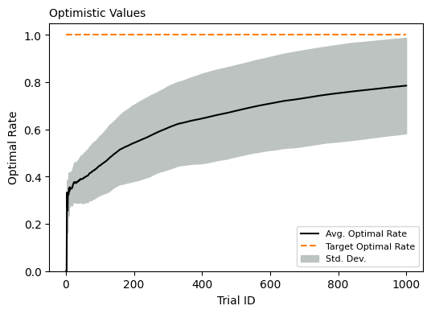

### Order Issue

Now, let's check if we still get varied results when changing the order of the goalkeepers

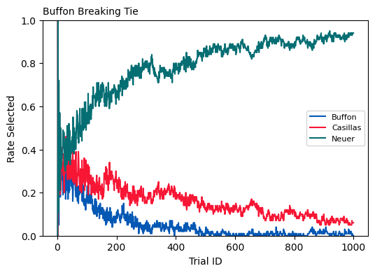

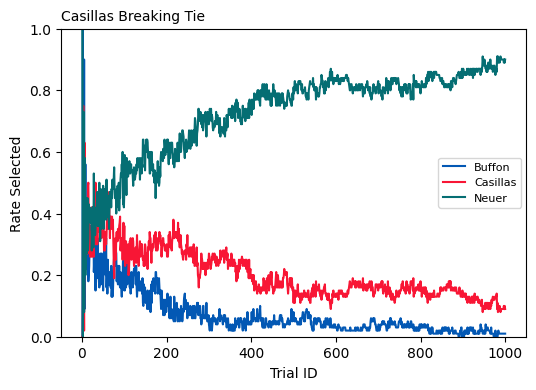

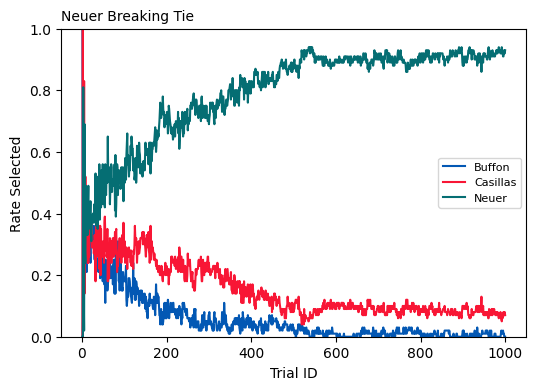

While there is slight variation, we can see that our results are independent of the order we put the goalkeepers in. This method solved our issue!

## Conclusion

*Is this new method solving our use case of selecting the best goalkeeper?*

In the Epsilon Greedy Method, after taking 500 shots we, on average, selected Neuer as our best goakeeper 60% of the time.

Using the Optimistic Values Method, we, on average, identify Neuer correctly 80% of the time after 500 shots. This is a significant improvement.

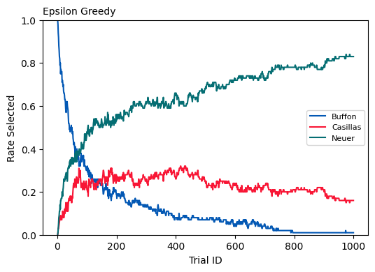

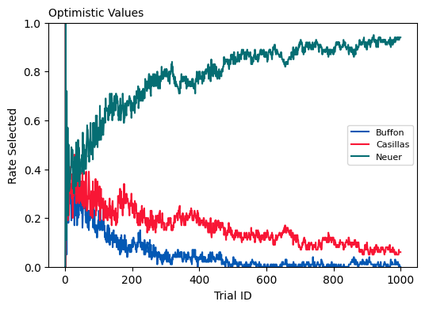

The analyst is pleased with the results. One drawback, however, is that this method does not estimate the true save rates of all goalkeepers. Instead, only the estimate for the top goalkeeper converges to the true rate.

The analyst wants to solve this issue before chatting with the coach again. He turns to a new method...

# Approach 4: UCB1

The analyst tries this modified experiment.

> Have each goalkeeper face one shot to initialize the results

> After this, each goalkeeper's estimated save rate is a sum between their observed save rate and an error/confidence bound. The error term will decrease as a goalkeeper faces more shots. Have the goalkeeper with the highest estimated save rate face the next shot.
- At the beginning of the experiment, the error term will be high forcing us to *explore* and have each goalkeeper face more shots.
- At the end of the experiment, the error term will be low, forcing us to *exploit* and choose the best goalkeeper more often.

## Simulation

### Code for Simulation

### Run Simulation

## Results

The analyst finds some notable results in the new approach:

- The chart in the top left shows that we begin by exloring and have each goalkeeper face a shot. Afterward, we exploit by selecting the best goalkeeper
- The chart in the top right shows we do not converge to our target save rate in experiments of 1000 shots; instead, our actual save rate stays below the target
- The chart in the middle left shows that our optimal rate is much lower than the optimistic values approach, but our variation is much smaller

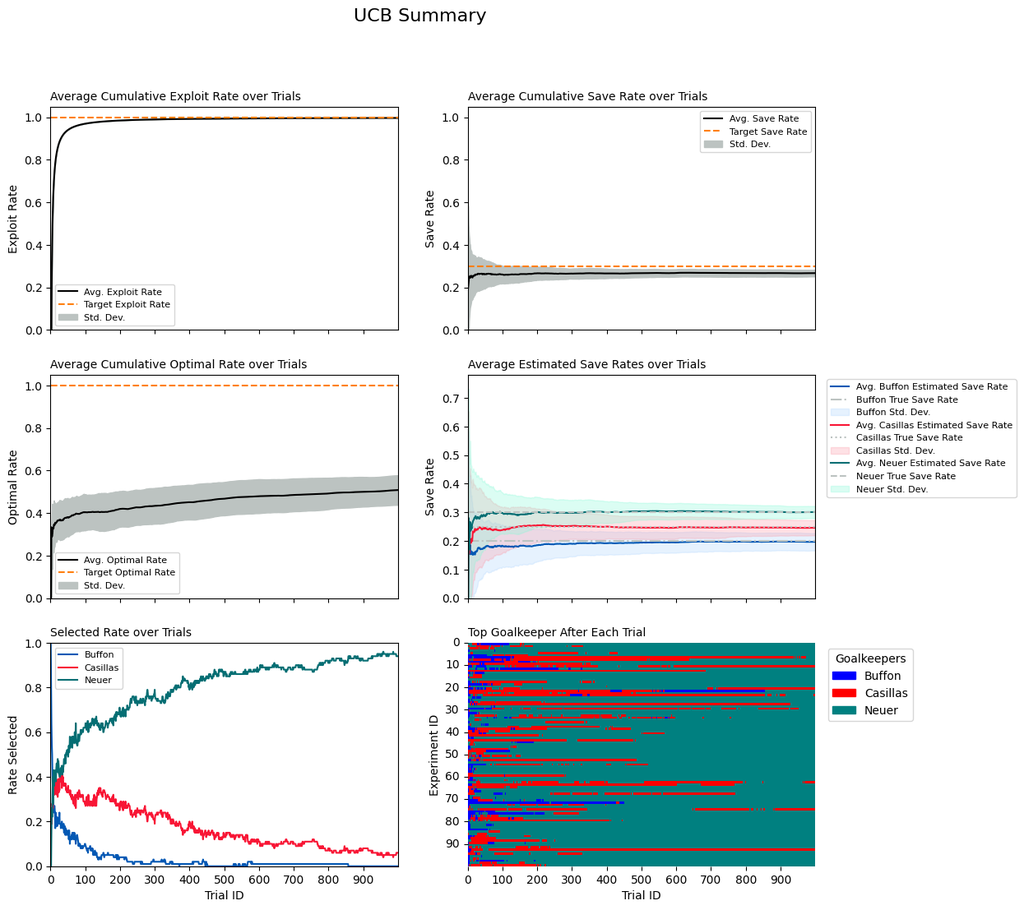

### Estimated Save Rates

Let's do a deep dive on the estimated save rate chart (middle right above).

- The UCB approach, much more accurately estimates each goalkeeper's save rate.
  - The epsilon greedy approach found the variation between the save rates for each goalkeeper, but the variation between experiments was much greater.
  - The Optimistic Values approach did not identify the save rates for the non-optimal goalkeepers (Buffon and Casillas)

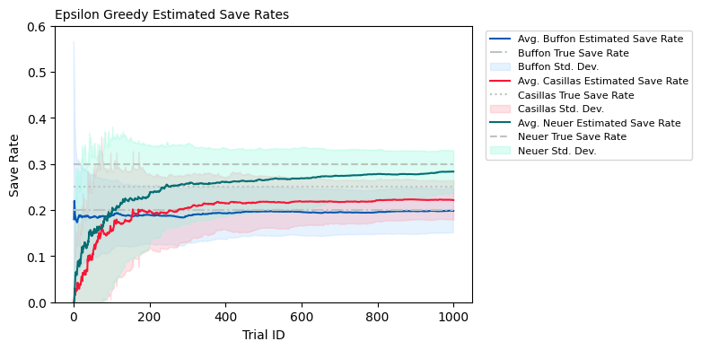

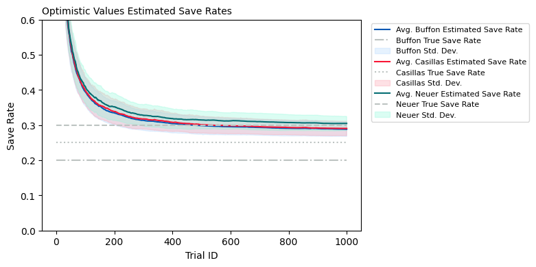

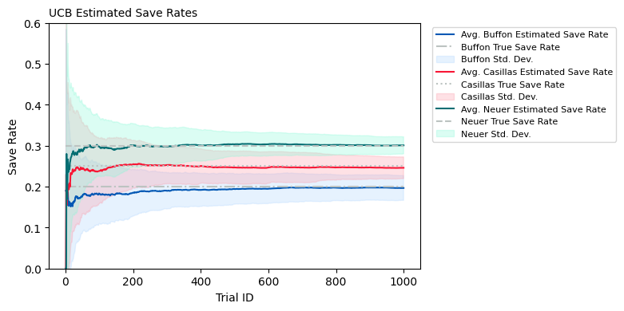

## Conclusion

*Is this new method solving our use case of selecting the best goalkeeper?*

Both the Optimistic Values and UCB approaches yield similar results in identifying Neuer as the best goalkeeper.

- Both take about 200 shots to correctly identify Neuer 60% of the time.
- Both take about 500 shots to correctly identify Neuer 80% of the time.
- Both take about 1000 shots to correctly identify Neuer 90% of the time.

The approaches differ however, on two main lines:

1. The Optimistic Values approach is much more efficient at having Neuer face more shots
   1. This approach would be prefereable if this experiment was taking place during competitive games, where having our optimal goalkeeper face as many shots as possible would be valuable
2. The UCB approach is more efficient at identifying the true save rate of each goalkeeper
   1. This approach would be preferable if the experiment is happening during training where the shots do not matter. Having accurate estimates would allow the coaching staff to weigh the cost of using a substitution to bring in a different goalkeeper

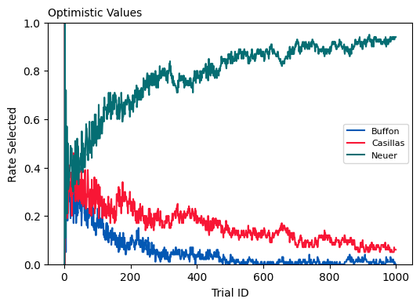

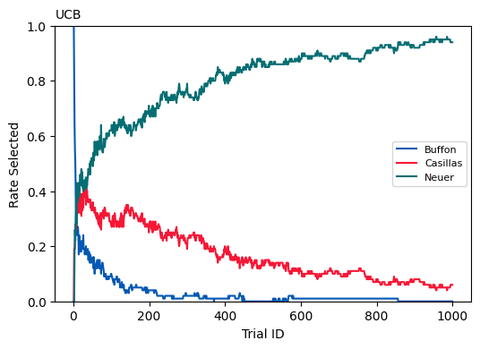

# Approach 5: Thompson Sampling

The analyst reviews these results with the coach. She is excited with the progress. An experiment of 500 shots is much more palatable, and she is relieved that the order in which the goalkeepers face shots no longer affects the results.

The coach and analyst discuss the tradeoff of having the best goalkeeper face as many shots as possible while also accurately estimating each goalkeeper's save rate. The coach understands the tradeoff, but asks the analyst if there is anything they could try to get *both*.

The analyst proposes one final experiment.

> Let our estimate of each goalkeeper's save rate be a [beta distribtion](https://en.wikipedia.org/wiki/Beta_distribution). Before each shot, randomly select a value from each goalkeeper's beta distribution. Have the goalkeeper with the highest value face the shot.

> After the goalkeeper faces the shot, update his beta distribution based on the result.

The beta distribution has a couple properties that make this work:

- It varies between 0 and 1 - our min and max save rates
- It is centered around it's mean which is our point estimate for each goalkeeper's save rate
- The more shots we face, the "skinnier" the distribution gets because we are more confident about each goalkeeper's save rate.
  - This naturally allows us to explore earlier in the experiment and exploit as we get more confident

## Simulation

### Code for Simulation

### Run Simulation

## Results

The analyst finds some notable results in the new approach:

- The chart in the middle left shows that:
  - this method does a *better job* of having the optimal goalkeeper face more shots than the UCB1 approach
  - this method does a *worse job* of having the optimal goalkeeper face more shots than the optimistic values approach
- The chart in the middle right shows that:
  - this method does a *better job* of estimating each goalkeeper's true save rate than the optimistic values approach
  - this method does a *worse job* of estimating each goalkeeper's true save rate than the UCB1 approach

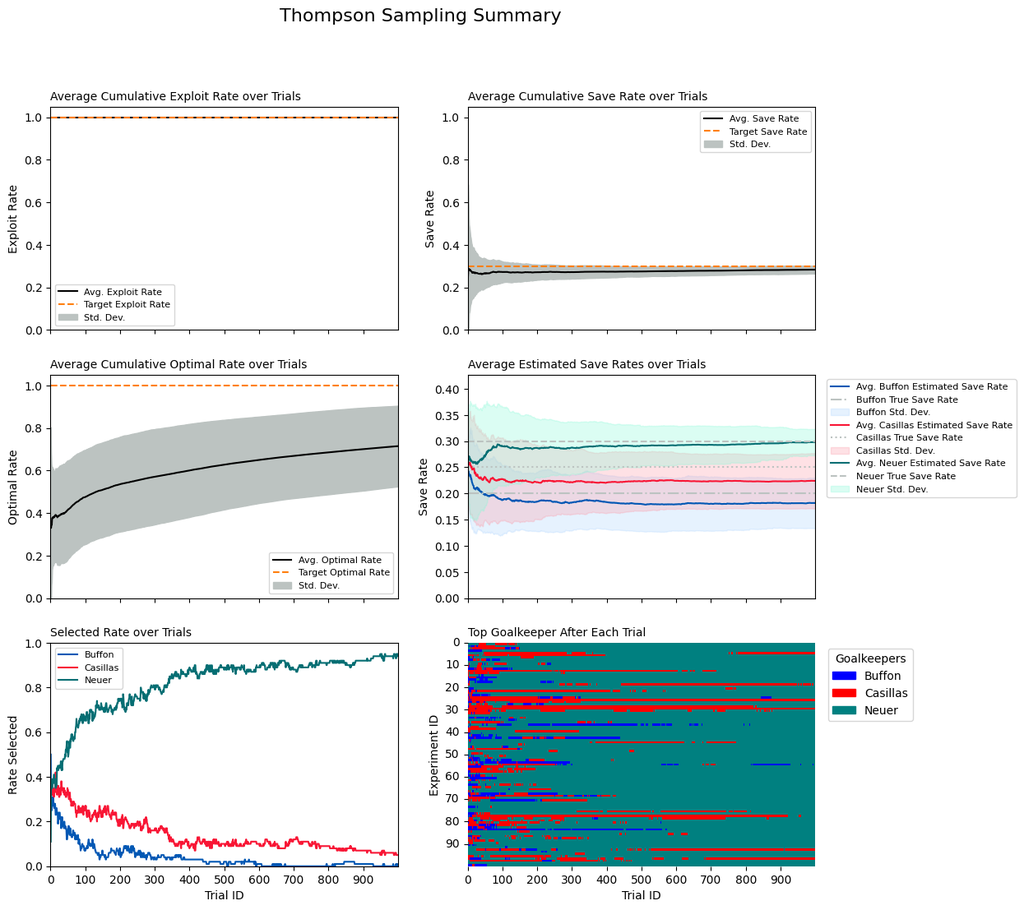

## Conclusion

*Is this new method solving our use case of selecting the best goalkeeper?*

This approach yields very similar results in identifying Neuer as the best goalkeeper. The Thompson Sampling approach is best described as the *Goldilocks approach*. It scores in the middle for both finding each goalkeeper's save rate and having the optimal goalkeeper face the most shots.

# The Real Experiment

## Which approach do we use?

It is now time for the real experiment. The coach and analyst meet one last time to select the appropriate approach.

Their main objective is selecting the correct goalkeeper. The coach wants to be 90% confident she has selected the best goalkeeper. The analyst compares each of the three methods on this metric.

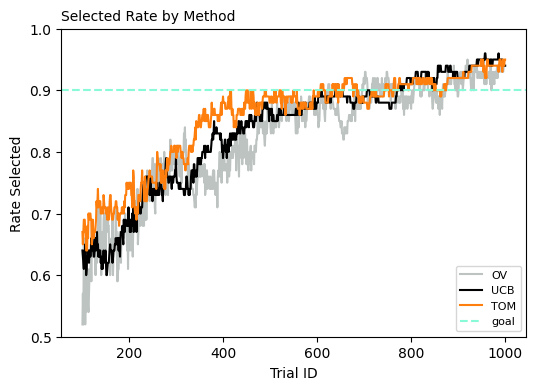

An experiment of 800 shots would yield the correct goaleeper with 90% confidence regardless of the method. The coach however, has two other objectives:

- The coach wants this experiment to last no more than 5 hours (one hour of training per day for a full week). She estimates we can take 2 shots per minute, so the experiment cannot last more than 600 shots.
- The coach also wants to know how much better the best goalkeeper is when compared to the others.

The anlyst proposes this approach:

> Run a Thompson Sampling experiment for 500 shots. This should estimate each goalkeeper's save rate reasonably well. We can also be about 85% confident we select the correct goalkeeper.

> This leaves us 100 shots at the end in case our results are inconclusive

The coach agrees. It's game time!

## The Experiment

After the experiment of 500 shots completes, here are our results:

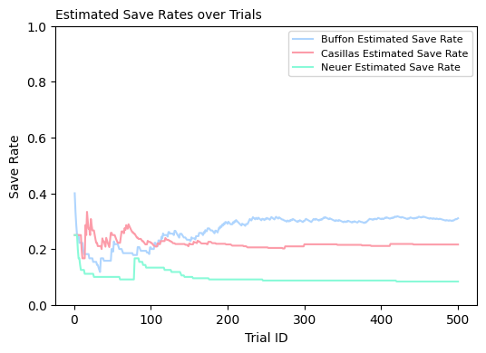

```
Our best goalkeeper is Buffon

Buffon's estimated save rate:  31.0%
Casillas' estimated save rate: 21.6%
Neuer's estimated save rate:    8.3%
```

Given the results, the coach is very confident that Buffon is the optimal goalkeeper. She now wants to spend the last 100 shots getting a more accurate estimate of each goalkeeper's save rate. That will help with the cost analysis of using a sub on a goalkeeper during a match.

> Have each goalkeeper face 30 more shots and update our estimate of their save save rate

```
Updated Buffon estimated save rate   : 30.3% (122 / 403)
Updated Casillas estimated save rate : 19.0% (26 / 137)
Updated Neuer estimated save rate    : 16.0% (8 / 50)
```

## Conclusion

Our experiment suggests that Buffon is the optimal goalkeeper for a penalty kick shootout. His save rate is about 10% higher than his peers.

The coach and her staff can use this data to determine whether to sub or not the next time they face a penalty shootout.